# Dictionary INS_Inschrijvingen

## DEM_Nationaliteit_EER_naam

| Feature | Result |
| --- | --- |
| Variable type | character |
| Number of missing obs. | 0 (0 %) |
| Number of unique values | 3 |
| Mode | “NL” |

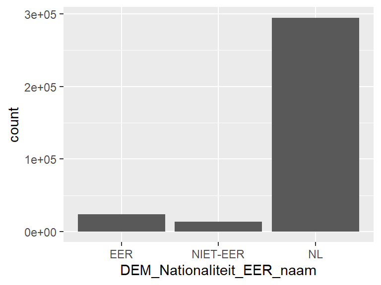

- Observed factor levels: "EER", "NIET-EER", "NL".

## DEM_Indicatie_nationaliteit_EER_actueel

| Feature | Result |
| --- | --- |
| Variable type | logical |
| Number of missing obs. | 0 (0 %) |
| Number of unique values | 2 |
| Mode | “FALSE” |

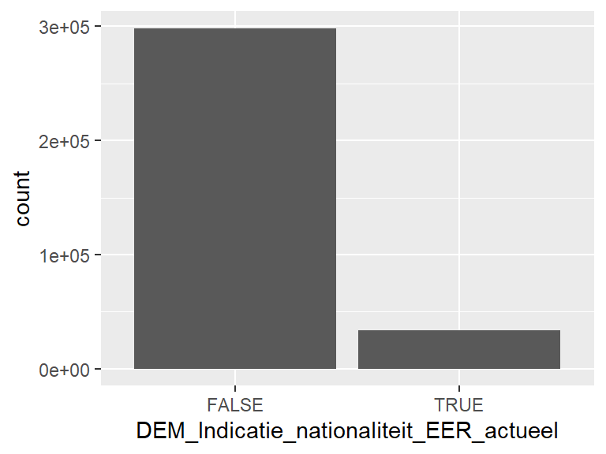

## DEM_Indicatie_nationaliteit_EER_peildatum

| Feature | Result |
| --- | --- |
| Variable type | logical |
| Number of missing obs. | 0 (0 %) |
| Number of unique values | 2 |
| Mode | “TRUE” |

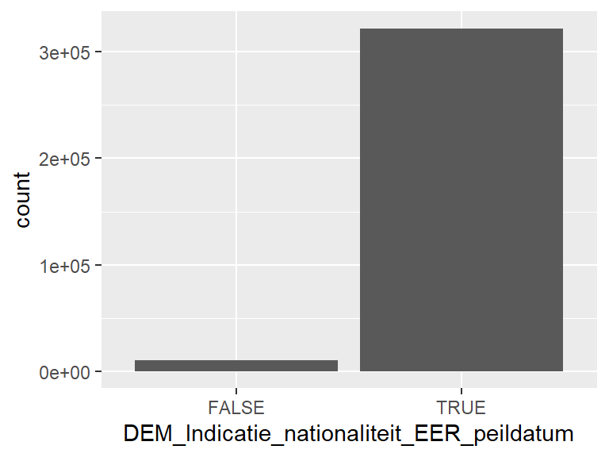

## DEM_Indicatie_internationale_student

| Feature | Result |
| --- | --- |
| Variable type | logical |
| Number of missing obs. | 0 (0 %) |
| Number of unique values | 2 |
| Mode | “TRUE” |

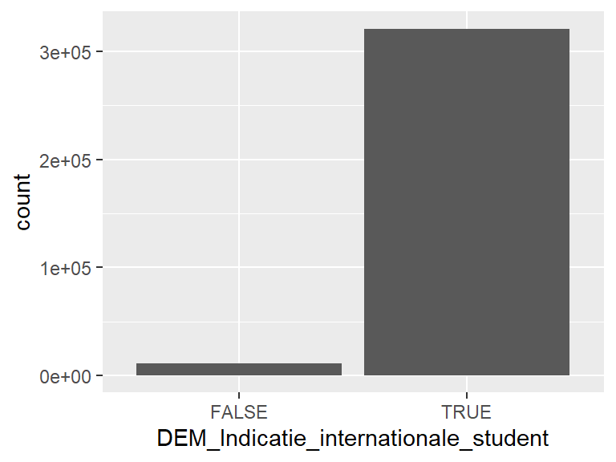

## INS_Verblijfsjaren_hoger_onderwijs_origineel

| Feature | Result |
| --- | --- |
| Variable type | numeric |
| Number of missing obs. | 14055 (4.23 %) |
| Number of unique values | 39 |
| Median | 4 |
| 1st and 3rd quartiles | 2; 6 |
| Min. and max. | 1; 39 |

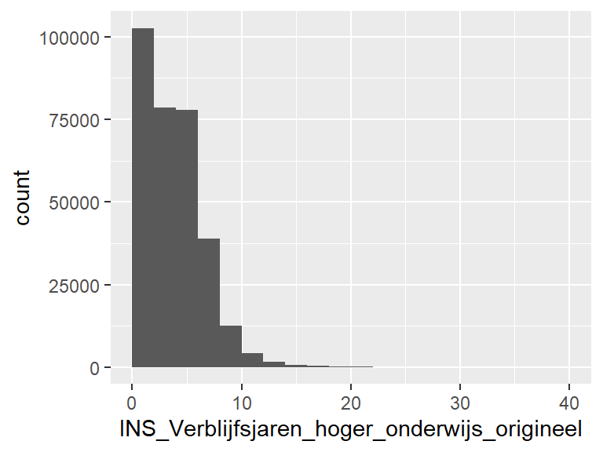

## OPL_Code_actueel

| Feature | Result |
| --- | --- |
| Variable type | integer |
| Number of missing obs. | 0 (0 %) |
| Number of unique values | 166 |
| Median | 56856 |
| 1st and 3rd quartiles | 54999; 60644 |
| Min. and max. | 50007; 69333 |

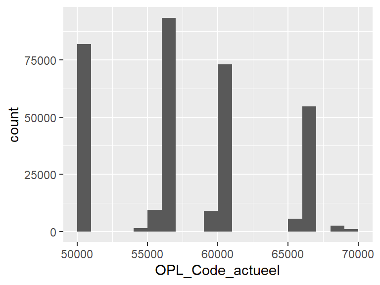

## INS_Vooropleiding_binnen_HO_sector

| Feature | Result |
| --- | --- |
| Variable type | character |
| Number of missing obs. | 0 (0 %) |
| Number of unique values | 70 |
| Mode | “vooropleiding onbekend” |

[figure not shown]

- Observed factor levels: "hbo-ad algemeen", "hbo-ad economie", "hbo-ad gedrag en maatschappij", "hbo-ad taal en cultuur", "hbo-ad techniek", …, "wo-pim gedrag en maatschappij", "wo-pim recht", "wo-vo/ma/bf gezondheidszorg", "wo-vo/ma/bf natuur", "wo-vo/ma/bf onderwijs" (60 values omitted).

## INS_Vooropleiding_voor_HO_profiel

| Feature | Result |
| --- | --- |
| Variable type | character |
| Number of missing obs. | 0 (0 %) |
| Number of unique values | 46 |
| Mode | “vwo profiel natuur/techniek & natuur/gezondheid” |

[figure not shown]

- Observed factor levels: "havo algemeen", "havo profiel cultuur & maatschappij", "havo profiel economie & maatschappij", "havo profiel economie/maatschappij & cultuur/maatschappij", "havo profiel natuur & gezondheid", …, "vwo profiel natuur/gezondheid & cultuur/maatschappij", "vwo profiel natuur/gezondheid & economie/maatschappij", "vwo profiel natuur/techniek & cultuur/maatschappij", "vwo profiel natuur/techniek & economie/maatschappij", "vwo profiel natuur/techniek & natuur/gezondheid" (36 values omitted).

## INS_Vooropleiding_voor_HO_omschrijving

| Feature | Result |
| --- | --- |
| Variable type | character |
| Number of missing obs. | 0 (0 %) |
| Number of unique values | 6 |
| Mode | “vwo” |

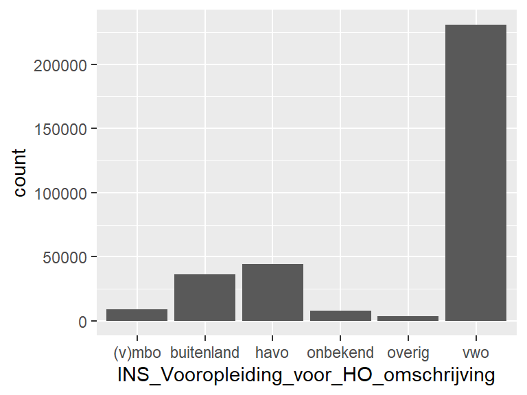

- Observed factor levels: "(v)mbo", "buitenland", "havo", "onbekend", "overig", "vwo".

## INS_Vooropleiding_binnen_HO_soort

| Feature | Result |
| --- | --- |
| Variable type | character |
| Number of missing obs. | 0 (0 %) |
| Number of unique values | 6 |
| Mode | “onbekend” |

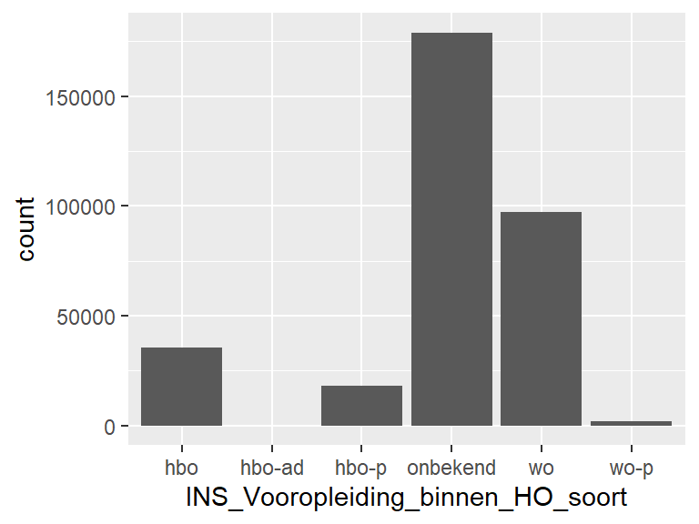

- Observed factor levels: "hbo", "hbo-ad", "hbo-p", "onbekend", "wo", "wo-p".

## INS_Hoogste_vooropleiding_nieuw_cat

| Feature | Result |
| --- | --- |
| Variable type | character |
| Number of missing obs. | 0 (0 %) |
| Number of unique values | 11 |
| Mode | “vwo” |

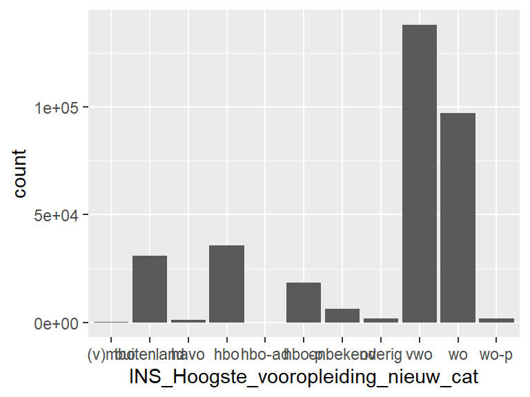

- Observed factor levels: "(v)mbo", "buitenland", "havo", "hbo", "hbo-ad", …, "onbekend", "overig", "vwo", "wo", "wo-p" (1 values omitted).

## INS_Vooropleiding_voor_HO_naam

| Feature | Result |
| --- | --- |
| Variable type | character |
| Number of missing obs. | 54298 (16.35 %) |
| Number of unique values | 627 |
| Mode | “ROC van Amsterdam” |

[figure not shown]

- Observed factor levels: "2College", "Adelbert College", "Aeres (V) MBO", "Agnieten College", "Albeda", …, "Zeldenrust Steelantcollege", "Zernike College", "Zuider Gymnasium", "Zuyderzee Lyceum", "Zwin College SGM" (617 values omitted).

## INS_Vooropleiding_binnen_HO_naam

| Feature | Result |
| --- | --- |
| Variable type | character |
| Number of missing obs. | 181303 (54.58 %) |
| Number of unique values | 137 |
| Mode | “Vrije Universiteit Amsterdam” |

[figure not shown]

- Observed factor levels: "Academie Artemis", "Aeres Hogeschool", "AG&AI", "Akad v Beeldende Kunst", "Amsterdamse Hogesch vd Kunsten", …, "Vrije Universiteit Amsterdam", "Webster University", "WU", "WUAS", "Zuyd Hogeschool" (127 values omitted).

## INS_Hoogste_vooropleiding_instellingsnaam

| Feature | Result |
| --- | --- |
| Variable type | character |
| Number of missing obs. | 43203 (13.01 %) |
| Number of unique values | 701 |
| Mode | “Vrije Universiteit Amsterdam” |

[figure not shown]

- Observed factor levels: "2College", "Academie Artemis", "Adelbert College", "Aeres Hogeschool", "AG&AI", …, "Zernike College", "Zuider Gymnasium", "Zuyd Hogeschool", "Zuyderzee Lyceum", "Zwin College SGM" (691 values omitted).

## INS_Vooropleiding_voor_HO_postcode

| Feature | Result |
| --- | --- |
| Variable type | numeric |
| Number of missing obs. | 54298 (16.35 %) |
| Number of unique values | 482 |
| Median | 2134 |
| 1st and 3rd quartiles | 1401; 3813 |
| Min. and max. | 1013; 9989 |

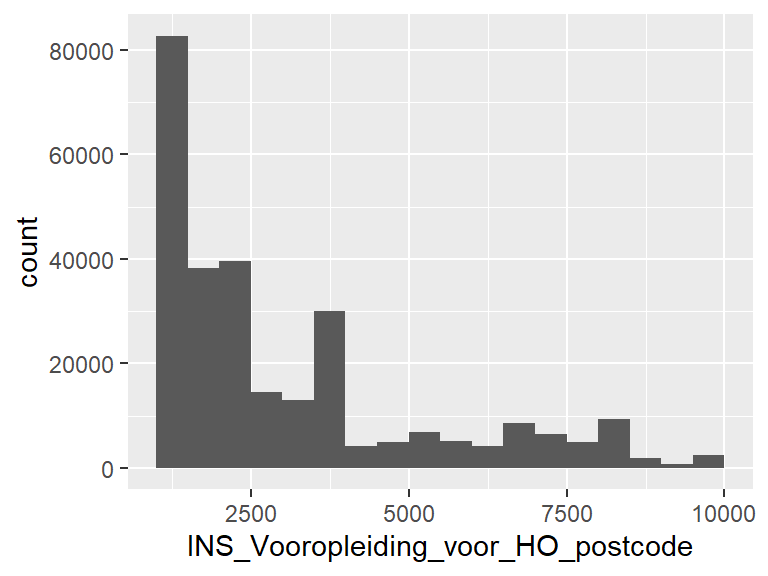

## INS_Vooropleiding_binnen_HO_postcode

| Feature | Result |
| --- | --- |
| Variable type | numeric |
| Number of missing obs. | 181307 (54.58 %) |
| Number of unique values | 98 |
| Median | 1081 |
| 1st and 3rd quartiles | 1081; 3072 |
| Min. and max. | 1011; 9747 |

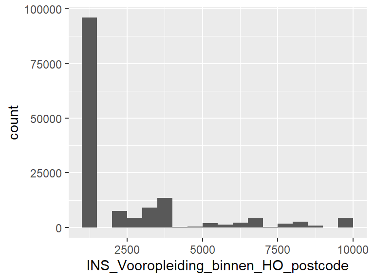

## INS_Hoogste_vooropleiding_postcode

| Feature | Result |
| --- | --- |
| Variable type | numeric |
| Number of missing obs. | 43207 (13.01 %) |
| Number of unique values | 506 |
| Median | 1509 |
| 1st and 3rd quartiles | 1081; 3511 |
| Min. and max. | 1011; 9989 |

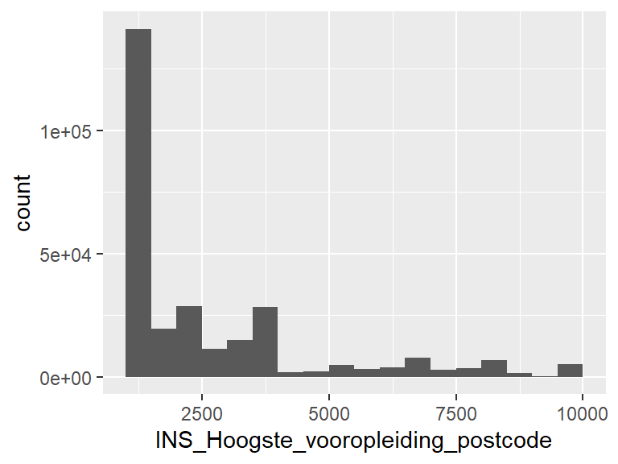

## INS_Vooropleiding_voor_HO_plaats

| Feature | Result |
| --- | --- |
| Variable type | character |
| Number of missing obs. | 54298 (16.35 %) |
| Number of unique values | 229 |
| Mode | “AMSTERDAM” |

[figure not shown]

- Observed factor levels: "’S-GRAVENHAGE", "’S-HERTOGENBOSCH", "AALTEN", "ALKMAAR", "ALMELO", …, "ZEVENBERGEN", "ZOETERMEER", "ZUTPHEN", "ZWIJNDRECHT", "ZWOLLE" (219 values omitted).

## INS_Vooropleiding_binnen_HO_plaats

| Feature | Result |
| --- | --- |
| Variable type | character |
| Number of missing obs. | 181303 (54.58 %) |
| Number of unique values | 46 |
| Mode | “AMSTERDAM” |

[figure not shown]

- Observed factor levels: "", "’S-GRAVENHAGE", "’S-HERTOGENBOSCH", "ALKMAAR", "AMERSFOORT", …, "VELP GLD", "VENLO", "VLISSINGEN", "WAGENINGEN", "ZWOLLE" (36 values omitted).

## INS_Hoogste_vooropleiding_plaats

| Feature | Result |
| --- | --- |
| Variable type | character |
| Number of missing obs. | 43203 (13.01 %) |
| Number of unique values | 233 |
| Mode | “AMSTERDAM” |

[figure not shown]

- Observed factor levels: "", "’S-GRAVENHAGE", "’S-HERTOGENBOSCH", "AALTEN", "ALKMAAR", …, "ZEVENBERGEN", "ZOETERMEER", "ZUTPHEN", "ZWIJNDRECHT", "ZWOLLE" (223 values omitted).

## INS_Examenresultaat

| Feature | Result |
| --- | --- |
| Variable type | character |
| Number of missing obs. | 256616 (77.25 %) |
| Number of unique values | 3 |
| Mode | “Examen behaald” |

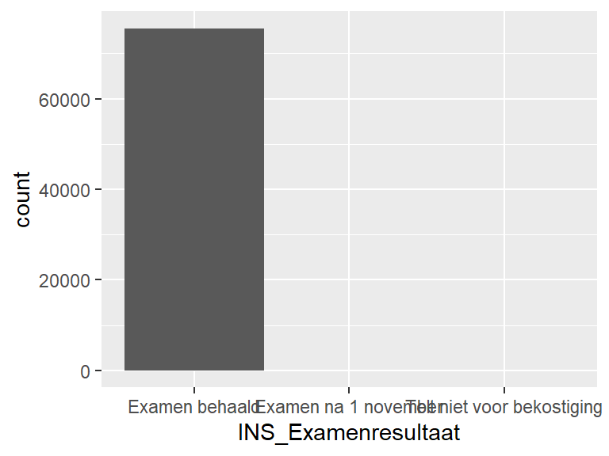

- Observed factor levels: "Examen behaald", "Examen na 1 november", "Telt niet voor bekostiging".

## INS_Indicatie_eerste_jaars_instelling_cat

| Feature | Result |
| --- | --- |
| Variable type | character |
| Number of missing obs. | 0 (0 %) |
| Number of unique values | 3 |
| Mode | “Ouderejaars VU” |

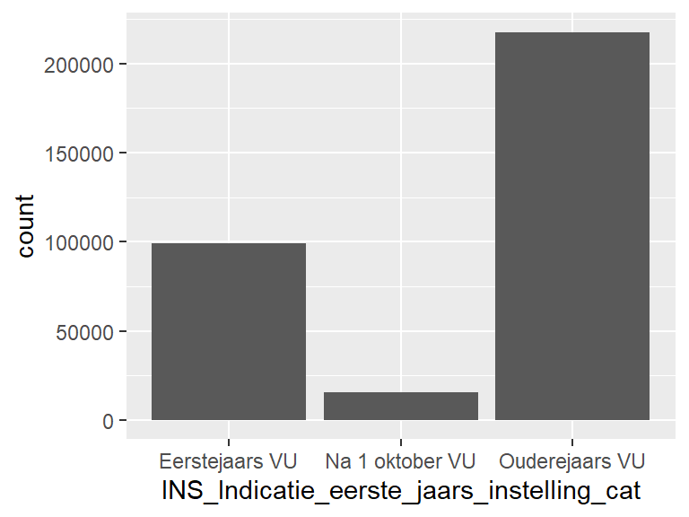

- Observed factor levels: "Eerstejaars VU", "Na 1 oktober VU", "Ouderejaars VU".

## INS_Indicatie_eerste_jaars_instelling_naam

| Feature | Result |
| --- | --- |
| Variable type | character |
| Number of missing obs. | 0 (0 %) |
| Number of unique values | 5 |
| Mode | “Hoofd - Ouderejaars VU” |

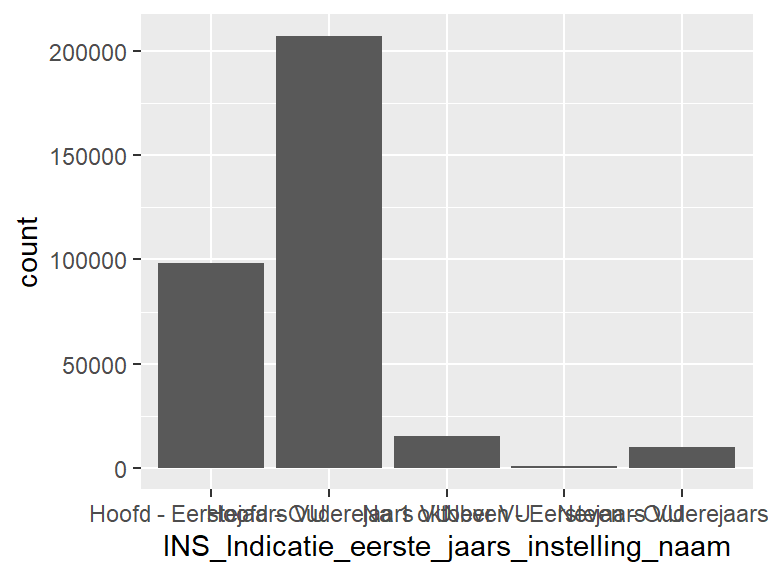

- Observed factor levels: "Hoofd - Eerstejaars VU ", "Hoofd - Ouderejaars VU", "Na 1 oktober VU", "Neven - Eerstejaars VU", "Neven - Ouderejaars VU".

## INS_Indicatie_eerste_jaars_opleiding_en_instelling_naam

| Feature | Result |
| --- | --- |
| Variable type | character |
| Number of missing obs. | 0 (0 %) |
| Number of unique values | 3 |
| Mode | “Ouderejaars opleiding” |

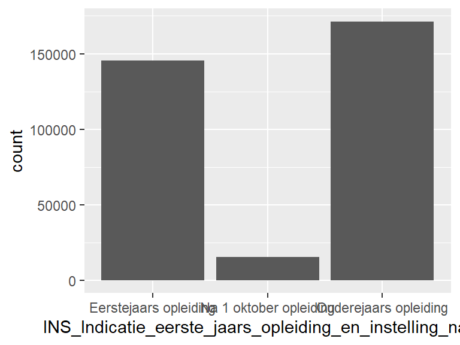

- Observed factor levels: "Eerstejaars opleiding", "Na 1 oktober opleiding", "Ouderejaars opleiding".

## DEM_Nationaliteit_1_naam

| Feature | Result |
| --- | --- |
| Variable type | character |
| Number of missing obs. | 0 (0 %) |
| Number of unique values | 149 |
| Mode | “Nederlandse” |

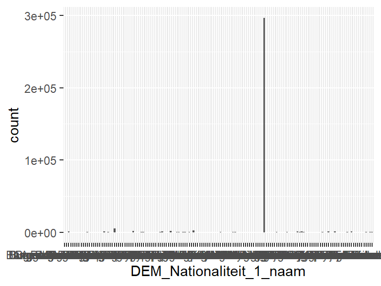

- Observed factor levels: "Afghaanse", "Albanese", "Amerikaans burger", "Amerikaans onderdaan", "Argentijnse", …, "Zuid-Afrikaanse", "Zuid-Koreaanse", "Zuid-Soedanese", "Zweedse", "Zwitserse" (139 values omitted).

## DEM_Nationaliteit_2_naam

| Feature | Result |
| --- | --- |
| Variable type | character |
| Number of missing obs. | 0 (0 %) |
| Number of unique values | 159 |
| Mode | “NULL” |

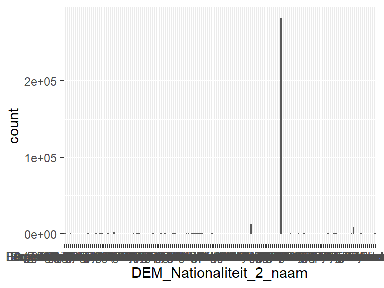

- Observed factor levels: "Afghaanse", "Albanese", "Algerijnse", "Amerikaans burger", "Amerikaans onderdaan", …, "Zimbabwaanse", "Zuid-Afrikaanse", "Zuid-Koreaanse", "Zweedse", "Zwitserse" (149 values omitted).

## DEM_Nationaliteit_3_naam

| Feature | Result |
| --- | --- |
| Variable type | character |
| Number of missing obs. | 0 (0 %) |
| Number of unique values | 60 |
| Mode | “NULL” |

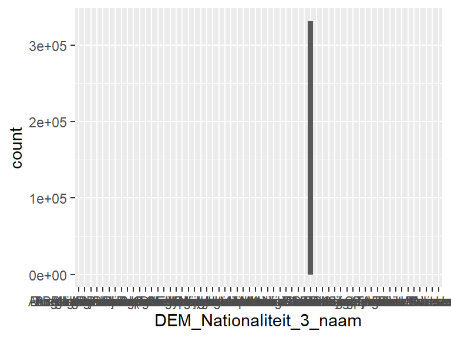

- Observed factor levels: "Albanese", "Algerijnse", "Amerikaans burger", "Amerikaans onderdaan", "Argentijnse", …, "Vietnamese", "Zuid-Afrikaanse", "Zuid-Koreaanse", "Zweedse", "Zwitserse" (50 values omitted).

## DEM_Leeftijd_peildatum_1_jan_cat

| Feature | Result |
| --- | --- |
| Variable type | factor |
| Number of missing obs. | 0 (0 %) |
| Number of unique values | 7 |
| Mode | “25 en ouder” |
| Reference category | Onder 18 |

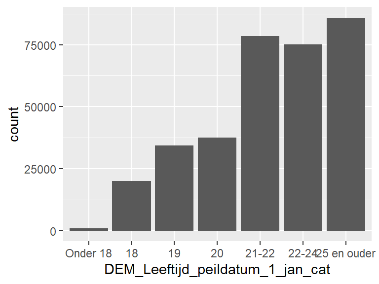

- Observed factor levels: "18", "19", "20", "21-22", "22-24", "25 en ouder", "Onder 18".

## INS_Soort_inschrijving_1CHO_cat

| Feature | Result |
| --- | --- |
| Variable type | character |
| Number of missing obs. | 0 (0 %) |
| Number of unique values | 4 |
| Mode | “Hoofdinschrijving” |

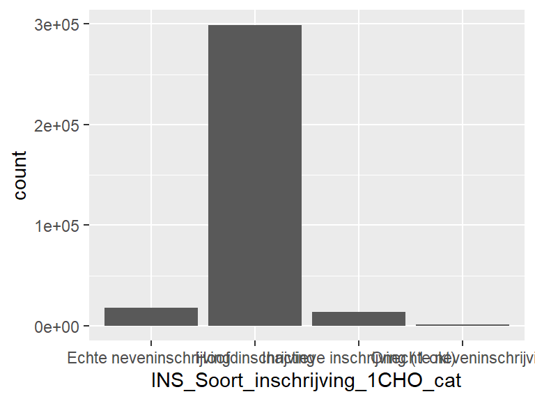

- Observed factor levels: "Echte neveninschrijving ", "Hoofdinschrijving", "Inactieve inschrijving (1 okt)", "Onechte neveninschrijving".

## INS_Vooropleiding_binnen_HO_Instellingsnaam

| Feature | Result |
| --- | --- |
| Variable type | character |
| Number of missing obs. | 181303 (54.58 %) |
| Number of unique values | 137 |
| Mode | “Vrije Universiteit Amsterdam” |

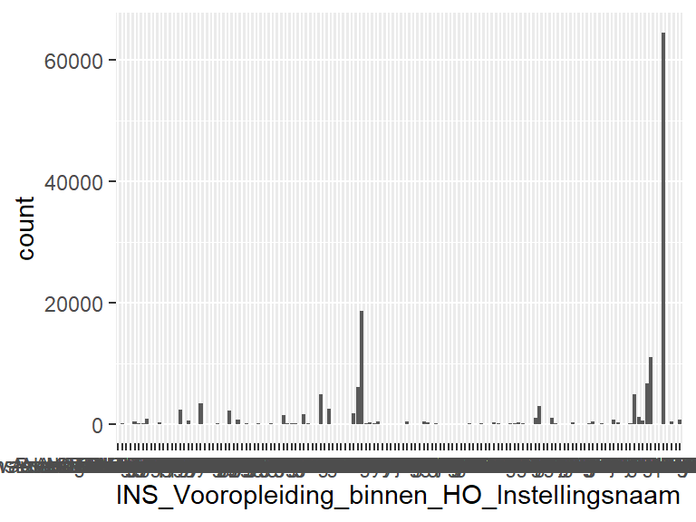

- Observed factor levels: "Academie Artemis", "Aeres Hogeschool", "AG&AI", "Akad v Beeldende Kunst", "Amsterdamse Hogesch vd Kunsten", …, "Vrije Universiteit Amsterdam", "Webster University", "WU", "WUAS", "Zuyd Hogeschool" (127 values omitted).

## INS_Vooropleiding_voor_HO_Instellingsnaam

| Feature | Result |
| --- | --- |
| Variable type | character |
| Number of missing obs. | 54298 (16.35 %) |
| Number of unique values | 627 |
| Mode | “ROC van Amsterdam” |

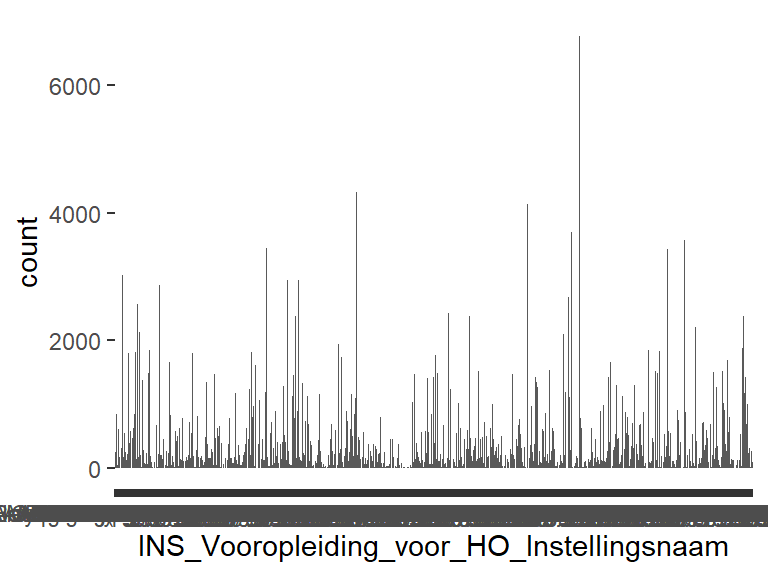

- Observed factor levels: "2College", "Adelbert College", "Aeres (V) MBO", "Agnieten College", "Albeda", …, "Zeldenrust Steelantcollege", "Zernike College", "Zuider Gymnasium", "Zuyderzee Lyceum", "Zwin College SGM" (617 values omitted).

## INS_Verblijfsjaren_wetenschappelijk_onderwijs_cat

| Feature | Result |
| --- | --- |
| Variable type | factor |
| Number of missing obs. | 14055 (4.23 %) |
| Number of unique values | 6 |
| Mode | “1” |
| Reference category | 0 |

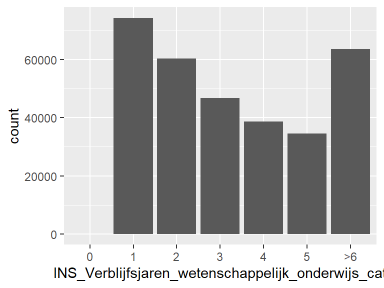

- Observed factor levels: ">6", "0", "1", "2", "3", "4", "5".

## INS_Verblijfsjaren_hoger_onderwijs_cat

| Feature | Result |
| --- | --- |
| Variable type | factor |
| Number of missing obs. | 14055 (4.23 %) |
| Number of unique values | 6 |
| Mode | “>6” |
| Reference category | 0 |

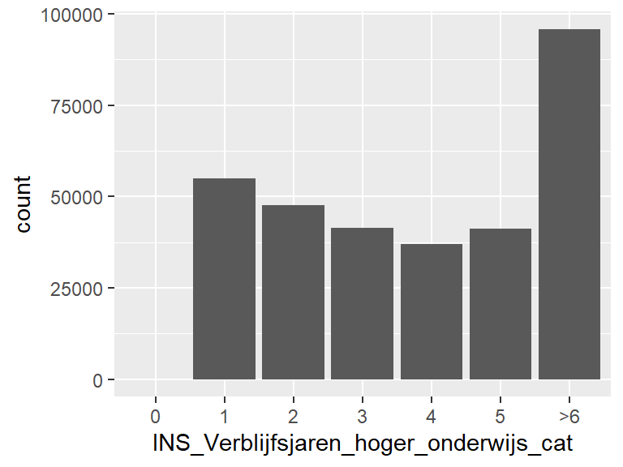

- Observed factor levels: ">6", "0", "1", "2", "3", "4", "5".

## INS_Uitwonend

| Feature | Result |
| --- | --- |
| Variable type | logical |
| Number of missing obs. | 56122 (16.9 %) |
| Number of unique values | 2 |
| Mode | “TRUE” |

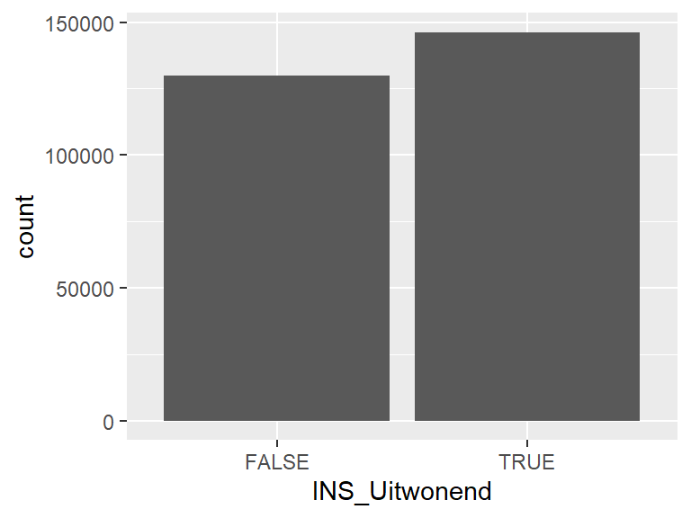

## INS_Vooropleiding_voor_HO_profiel_standaard

| Feature | Result |
| --- | --- |
| Variable type | character |
| Number of missing obs. | 63247 (19.04 %) |
| Number of unique values | 10 |
| Mode | “economie & maatschappij” |

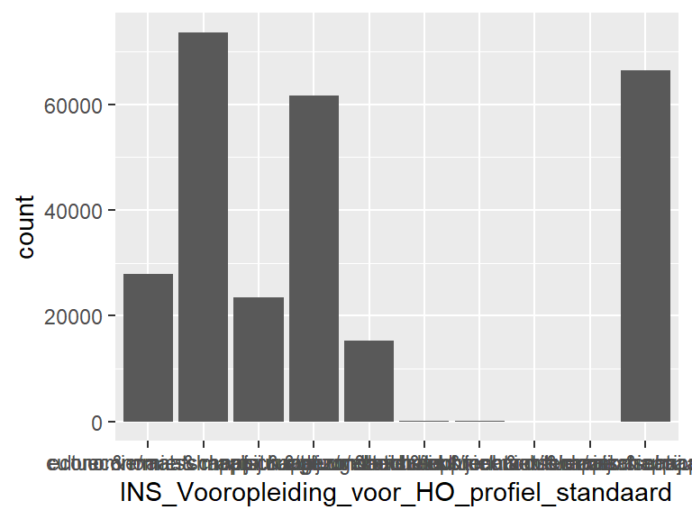

- Observed factor levels: "cultuur & maatschappij", "economie & maatschappij", "economie/maatschappij & cultuur/maatschappij", "natuur & gezondheid", "natuur & techniek", "natuur/gezondheid & cultuur/maatschappij", "natuur/gezondheid & economie/maatschappij", "natuur/techniek & cultuur/maatschappij", "natuur/techniek & economie/maatschappij", "natuur/techniek & natuur/gezondheid".

## INS_Vooropleiding_voor_HO_profiel_standaard_alleen_VWO

| Feature | Result |
| --- | --- |
| Variable type | character |
| Number of missing obs. | 105842 (31.86 %) |
| Number of unique values | 10 |
| Mode | “natuur/techniek & natuur/gezondheid” |

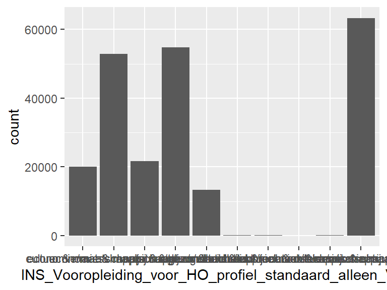

- Observed factor levels: "cultuur & maatschappij", "economie & maatschappij", "economie/maatschappij & cultuur/maatschappij", "natuur & gezondheid", "natuur & techniek", "natuur/gezondheid & cultuur/maatschappij", "natuur/gezondheid & economie/maatschappij", "natuur/techniek & cultuur/maatschappij", "natuur/techniek & economie/maatschappij", "natuur/techniek & natuur/gezondheid".

## INS_Vooropleiding_voor_HO_profiel_standaard_NT

| Feature | Result |
| --- | --- |
| Variable type | logical |
| Number of missing obs. | 0 (0 %) |
| Number of unique values | 2 |
| Mode | “FALSE” |

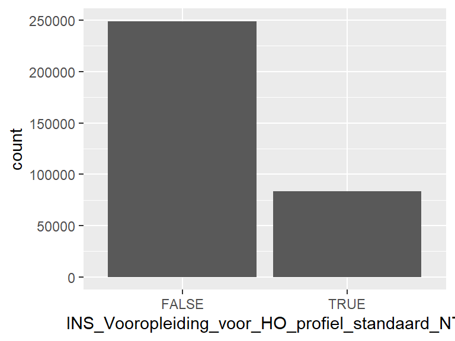

## INS_Vooropleiding_voor_HO_profiel_standaard_NG

| Feature | Result |
| --- | --- |
| Variable type | logical |
| Number of missing obs. | 0 (0 %) |
| Number of unique values | 2 |
| Mode | “FALSE” |

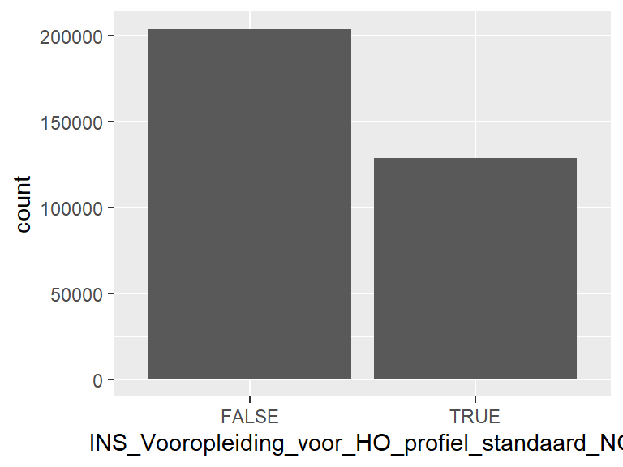

## INS_Vooropleiding_voor_HO_profiel_standaard_EM

| Feature | Result |
| --- | --- |
| Variable type | logical |
| Number of missing obs. | 0 (0 %) |
| Number of unique values | 2 |
| Mode | “FALSE” |

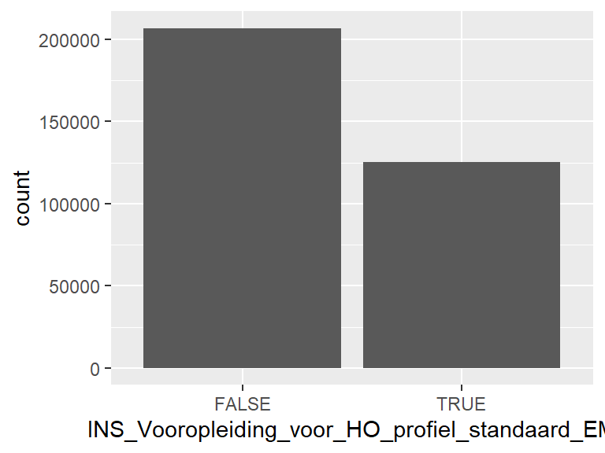

## INS_Vooropleiding_voor_HO_profiel_standaard_CM

| Feature | Result |
| --- | --- |
| Variable type | logical |
| Number of missing obs. | 0 (0 %) |
| Number of unique values | 2 |
| Mode | “FALSE” |

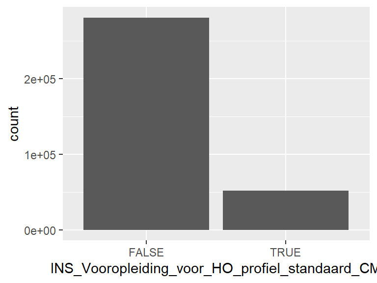

## INS_Vooropleiding_voor_HO_profiel_standaard_alleen_VWO_combinatieprofiel

| Feature | Result |
| --- | --- |
| Variable type | logical |
| Number of missing obs. | 105842 (31.86 %) |
| Number of unique values | 2 |
| Mode | “FALSE” |

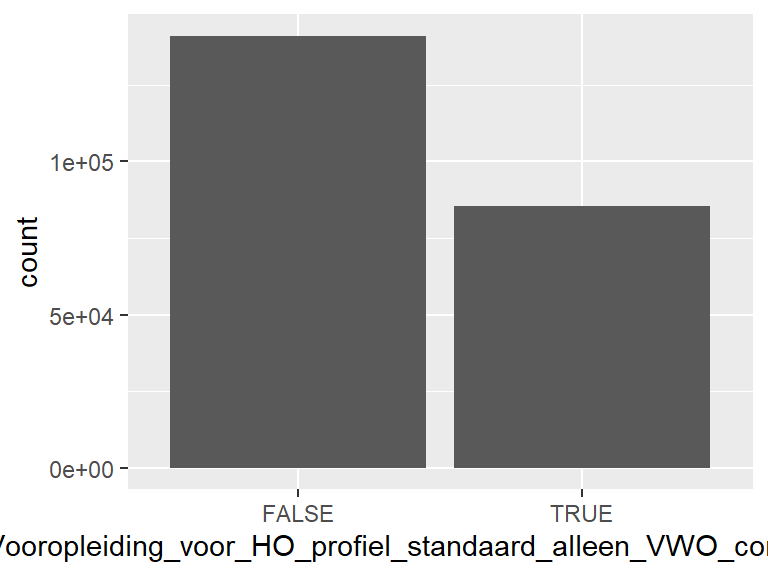

## INS_Vooropleiding_voor_HO_profiel_standaard_afk

| Feature | Result |
| --- | --- |
| Variable type | character |
| Number of missing obs. | 63247 (19.04 %) |
| Number of unique values | 10 |
| Mode | “EM” |

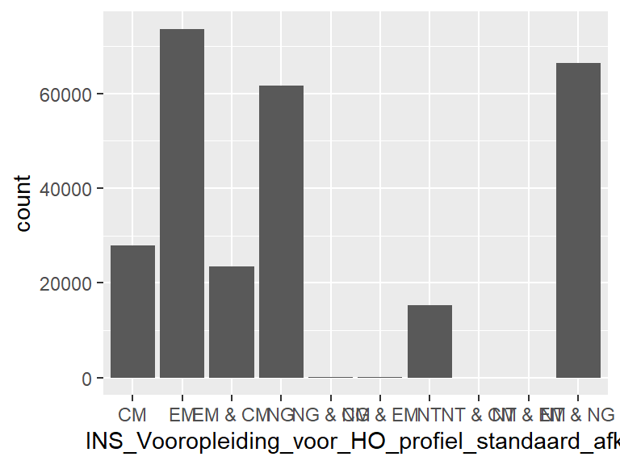

- Observed factor levels: "CM", "EM", "EM & CM", "NG", "NG & CM", "NG & EM", "NT", "NT & CM", "NT & EM", "NT & NG".

## INS_Vooropleiding_voor_HO_profiel_standaard_alleen_VWO_afk

| Feature | Result |
| --- | --- |
| Variable type | character |
| Number of missing obs. | 105842 (31.86 %) |
| Number of unique values | 10 |
| Mode | “NT & NG” |

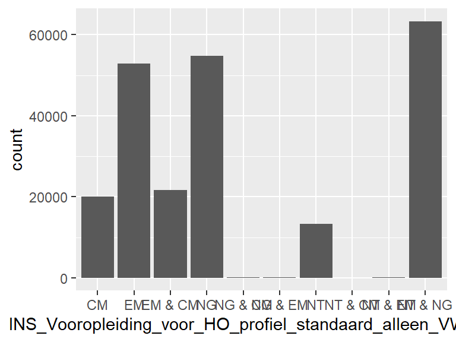

- Observed factor levels: "CM", "EM", "EM & CM", "NG", "NG & CM", "NG & EM", "NT", "NT & CM", "NT & EM", "NT & NG".

## INS_Vooropleiding_voor_HO_profiel_standaard_zonder_combinatie

- The variable only takes one value: "NA".

## INS_Vooropleiding_voor_HO_profiel_standaard_alleen_VWO_zonder_combinatie

- The variable only takes one value: "NA".

## INS_Soort_eerstejaars_code

| Feature | Result |
| --- | --- |
| Variable type | numeric |
| Number of missing obs. | 4142 (1.25 %) |
| Number of unique values | 4 |
| Median | 2 |
| 1st and 3rd quartiles | 1; 4 |
| Min. and max. | 1; 4 |

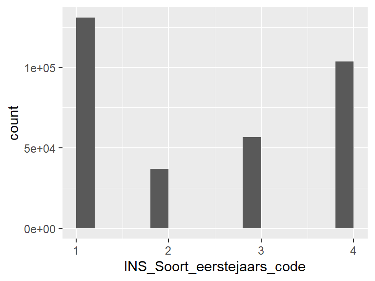

## INS_Aantal_inschrijvingen_in_HO

| Feature | Result |
| --- | --- |
| Variable type | numeric |
| Number of missing obs. | 4142 (1.25 %) |
| Number of unique values | 9 |
| Median | 1 |
| 1st and 3rd quartiles | 1; 1 |
| Min. and max. | 1; 11 |

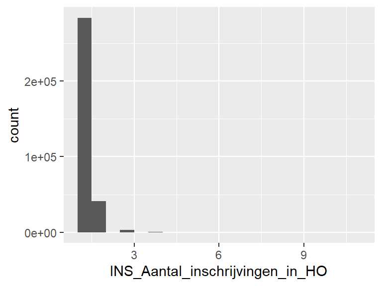

## INS_Herinschrijving_na_1_jaar

| Feature | Result |
| --- | --- |
| Variable type | numeric |
| Number of missing obs. | 17133 (5.16 %) |
| Number of unique values | 12 |
| Median | 1 |
| 1st and 3rd quartiles | 1; 1 |
| Min. and max. | 1; 12 |

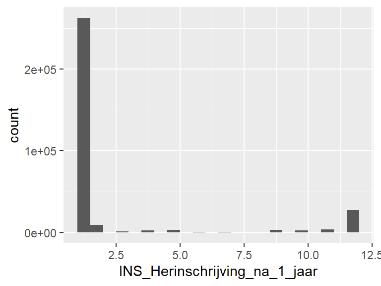

## INS_Herinschrijving_na_2_jaar

| Feature | Result |
| --- | --- |
| Variable type | numeric |
| Number of missing obs. | 40221 (12.11 %) |
| Number of unique values | 12 |
| Median | 1 |
| 1st and 3rd quartiles | 1; 9 |
| Min. and max. | 1; 12 |

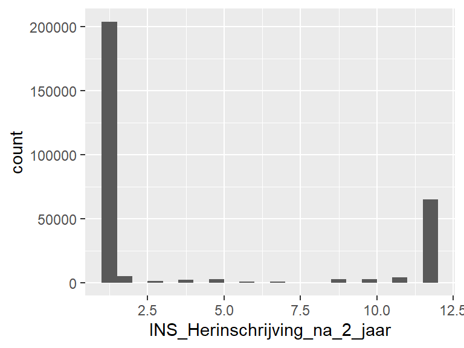

## INS_Herinschrijving_na_3_jaar

| Feature | Result |
| --- | --- |
| Variable type | numeric |
| Number of missing obs. | 70865 (21.33 %) |
| Number of unique values | 12 |
| Median | 2 |
| 1st and 3rd quartiles | 1; 12 |
| Min. and max. | 1; 12 |

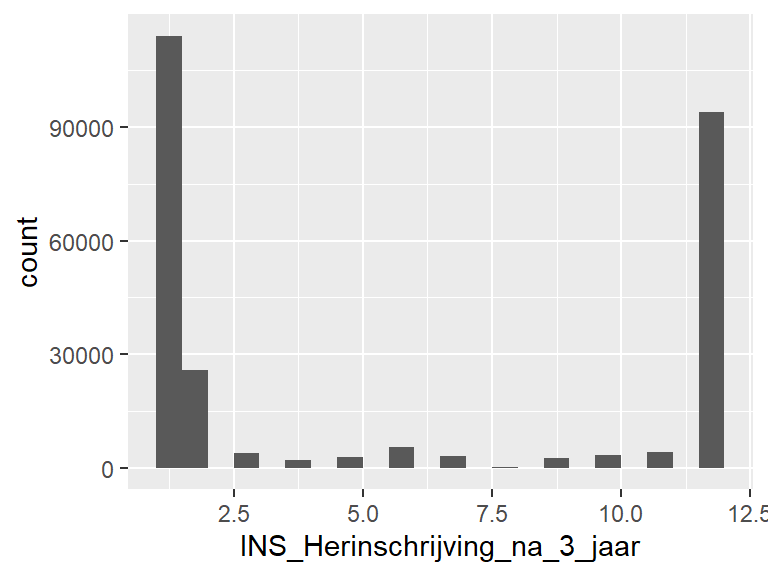

## INS_Herinschrijving_na_4_jaar

| Feature | Result |
| --- | --- |
| Variable type | numeric |
| Number of missing obs. | 101968 (30.7 %) |
| Number of unique values | 12 |
| Median | 10 |
| 1st and 3rd quartiles | 2; 12 |
| Min. and max. | 1; 12 |

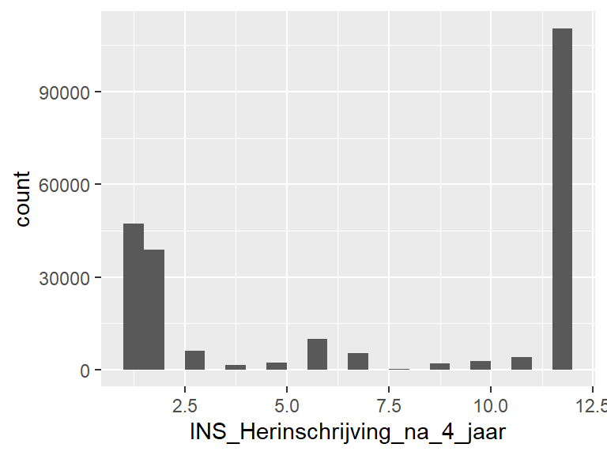

## INS_Herinschrijving_na_5_jaar

| Feature | Result |
| --- | --- |
| Variable type | numeric |
| Number of missing obs. | 130464 (39.28 %) |
| Number of unique values | 12 |
| Median | 12 |
| 1st and 3rd quartiles | 2; 12 |
| Min. and max. | 1; 12 |

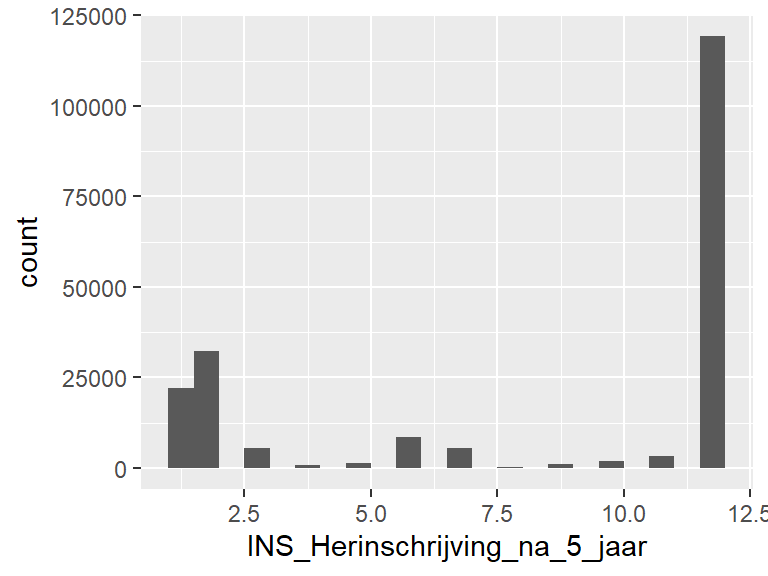

## INS_Herinschrijving_na_6_jaar

| Feature | Result |
| --- | --- |
| Variable type | numeric |
| Number of missing obs. | 155827 (46.91 %) |
| Number of unique values | 12 |
| Median | 12 |
| 1st and 3rd quartiles | 7; 12 |
| Min. and max. | 1; 12 |

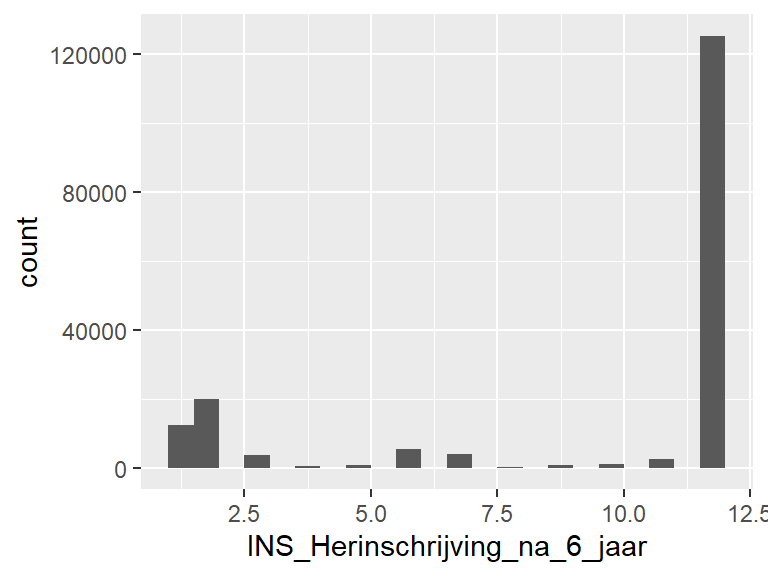

## INS_Herinschrijving_na_7_jaar

| Feature | Result |
| --- | --- |
| Variable type | integer |
| Number of missing obs. | 179677 (54.09 %) |
| Number of unique values | 12 |
| Median | 12 |
| 1st and 3rd quartiles | 12; 12 |
| Min. and max. | 1; 12 |

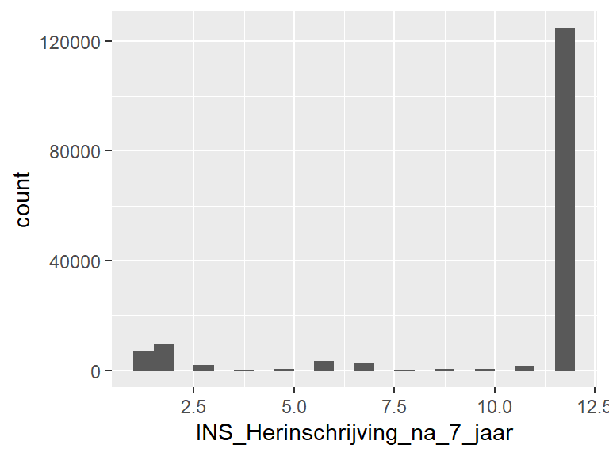

## INS_Herinschrijving_na_8_jaar

| Feature | Result |
| --- | --- |
| Variable type | integer |
| Number of missing obs. | 201830 (60.76 %) |
| Number of unique values | 12 |
| Median | 12 |
| 1st and 3rd quartiles | 12; 12 |
| Min. and max. | 1; 12 |

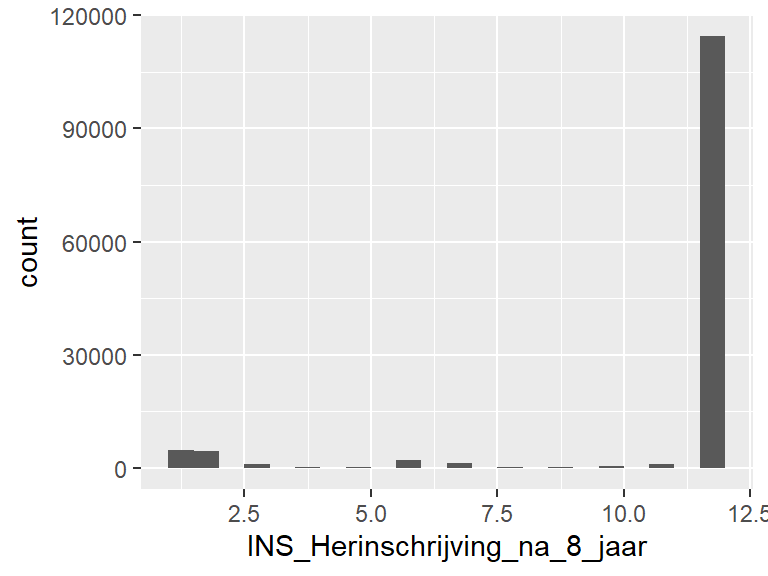

## INS_Examen_na_1_jaar

| Feature | Result |
| --- | --- |
| Variable type | character |
| Number of missing obs. | 17133 (5.16 %) |
| Number of unique values | 9 |
| Mode | “x” |

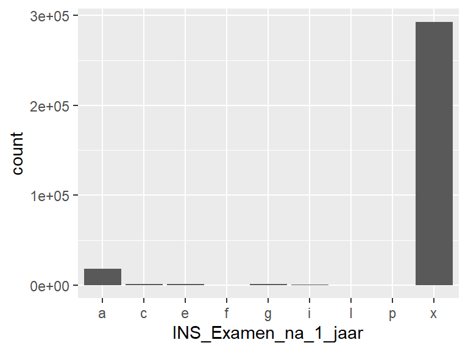

- Observed factor levels: "a", "c", "e", "f", "g", "i", "l", "p", "x".

## INS_Examen_na_2_jaar

| Feature | Result |
| --- | --- |
| Variable type | character |
| Number of missing obs. | 40221 (12.11 %) |
| Number of unique values | 11 |
| Mode | “x” |

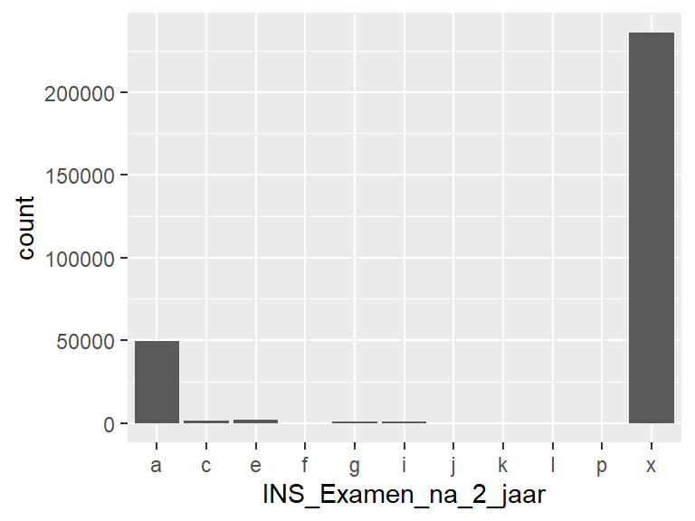

- Observed factor levels: "a", "c", "e", "f", "g", …, "j", "k", "l", "p", "x" (1 values omitted).

## INS_Examen_na_3_jaar

| Feature | Result |
| --- | --- |
| Variable type | character |
| Number of missing obs. | 70865 (21.33 %) |
| Number of unique values | 10 |
| Mode | “x” |

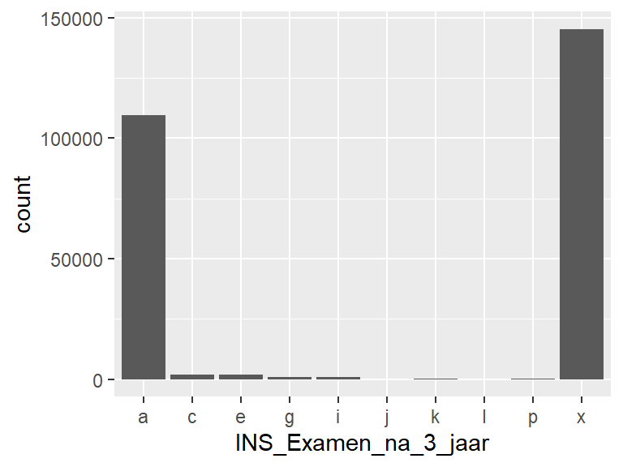

- Observed factor levels: "a", "c", "e", "g", "i", "j", "k", "l", "p", "x".

## INS_Examen_na_4_jaar

| Feature | Result |
| --- | --- |
| Variable type | character |
| Number of missing obs. | 101968 (30.7 %) |
| Number of unique values | 10 |
| Mode | “a” |

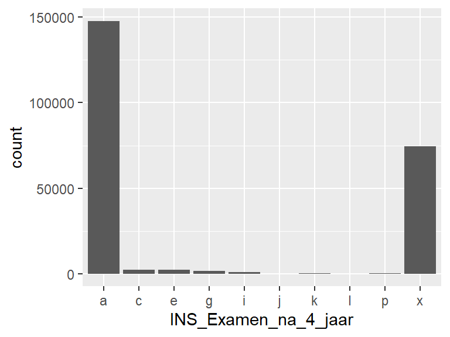

- Observed factor levels: "a", "c", "e", "g", "i", "j", "k", "l", "p", "x".

## INS_Examen_na_5_jaar

| Feature | Result |
| --- | --- |
| Variable type | character |
| Number of missing obs. | 130464 (39.28 %) |
| Number of unique values | 10 |
| Mode | “a” |

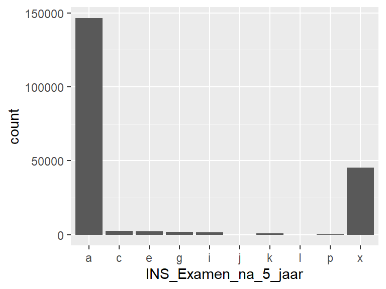

- Observed factor levels: "a", "c", "e", "g", "i", "j", "k", "l", "p", "x".

## INS_Examen_na_6_jaar

| Feature | Result |
| --- | --- |
| Variable type | character |
| Number of missing obs. | 155827 (46.91 %) |
| Number of unique values | 10 |
| Mode | “a” |

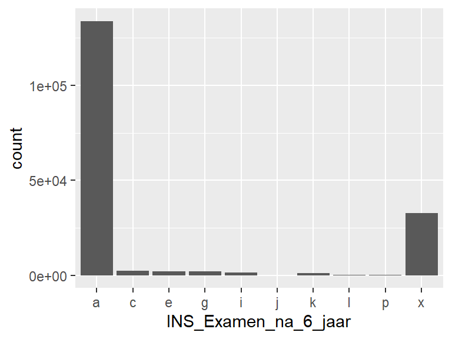

- Observed factor levels: "a", "c", "e", "g", "i", "j", "k", "l", "p", "x".

## INS_Examen_na_7_jaar

| Feature | Result |
| --- | --- |
| Variable type | character |
| Number of missing obs. | 179677 (54.09 %) |
| Number of unique values | 10 |
| Mode | “a” |

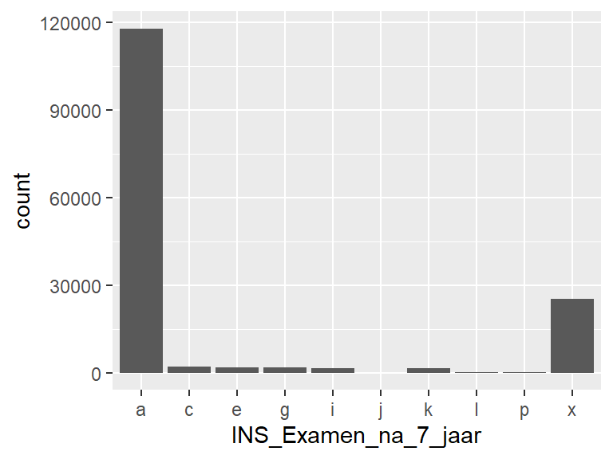

- Observed factor levels: "a", "c", "e", "g", "i", "j", "k", "l", "p", "x".